# **APC308 - Data Mining**

## Lab: Data Visualization

At the end of this lab session, you will be able to:

- Use Matplotlib for data visualization.
- Use the Seaborn library to plot various graphs.

# 1. Matplotlib Refresher

- A Matplotlib resource acompanies this part of the lab session. Follow along.
- The [official Matplotlib site](https://matplotlib.org/) has many useful goodies. Check it out.

# 2. What is Seaborn?

- [Seaborn](https://seaborn.pydata.org/) is a Python data visualization library based on matplotlib.
- Some of its attractive features are the beautiful default styles, simpler codes, and its ease of integration with the data structures of Pandas such as `DataFrame`. Note that Matplotlib predated Pandas by more than a decade. Seaborn which is based on Matplotlib is Pandas-aware.
- It is a useful add-on to help you do exploratory analysis and understanding of data. As the saying goes, "A picture is worth a thousand words".
- It can be installed from PyPI using `pip` or using `conda` (included as part of Anaconda distro).

  ```
  pip install seaborn             # for pip
  conda install seaborn           # for conda
  ```

## Getting Started with Seaborn

We shall explore the following next:

1. A glimpse of Matplotlib vs Seaborn
2. Plotting basic graphs using Seaborn

### 1. A Glimpse of Matplotlib vs Seaborn

```python
# Demo of using Matplotlib

import matplotlib.pyplot as plt
import numpy as np

plt.style.use('classic')
%matplotlib inline
```

```python
# Create some data for plotting

x = np.linspace(10, 20, 1000)
y = np.cumsum(np.random.randn(1000))
```

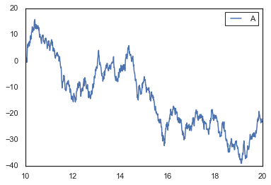

```python
# plot the data using Matplotlib defaults

plt.plot(x, y)
plt.legend('A', loc='upper right');
```

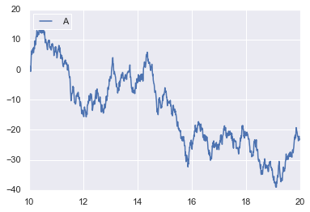

```python
# Now, let us do the same plotting using Seaborn
import seaborn as sns
#sns.set()
sns.set(style="darkgrid")              # other styles: whitegrid, darkgrid, dark, etc

plt.plot(x, y)
plt.legend('A', loc='upper left');
```

### Loading Data

- You would recall the read_csv(), read_excel(), etc methods of Pandas.
- Seaborn offers the `load_dataset()` method for loading example datasets. The `get_dataset_names()` method shows a list of available datasets.

```python
sns.get_dataset_names()

#iris = sns.load_dataset("iris")

#iris

#type(iris)
```

```
['anagrams',
 'anscombe',
 'attention',
 'brain_networks',
 'car_crashes',
 'diamonds',
 'dots',
 'exercise',
 'flights',
 'fmri',
 'gammas',
 'geyser',
 'iris',
 'mpg',
 'penguins',
 'planets',
 'taxis',
 'tips',
 'titanic']
```

### Activity!

You would recall that in the previous session on Pandas, you used some functions and attributes such as `tail()`, `describe()`, `info()`, `dtypes`, etc as well as operations (e.g. selection). Try them at this point.

```python
# Your code goes here
```

## 2. Plotting Various Graphs

- Seaborn allows you to plot a number of graph types with ease.
- Here is the [API reference](http://seaborn.pydata.org/api.html) you may refer to for various plots.
- We now shall see some of the basic plot types.

### A. Line Graph

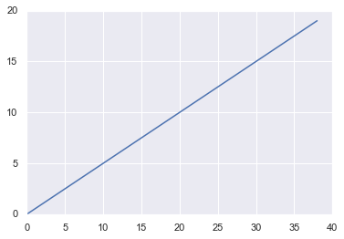

```python
# simple plot using lineplot()

import warnings                          # to silence warning if need be
warnings.filterwarnings('ignore')

x = [i for i in range(20)]
y = [j*2 for j in range(20)]

sns.lineplot(y,x)
```

```
[Text(0.5, 0, 'X-Axis'), Text(0, 0.5, 'Y-Axis')]
```

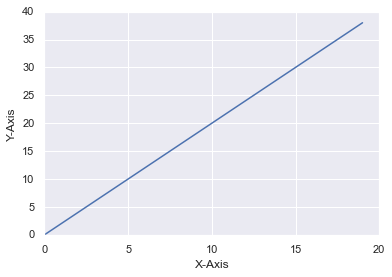

```python
# Setting xlabel and ylabel
p = sns.lineplot(x,y)

p.set( xlabel = "X-Axis", ylabel = "Y-Axis")
```

```python
# plotting from a dataset

tipData = sns.load_dataset("tips")

tipData
```

|  | total_bill | tip | sex | smoker | day | time | size |
| --- | --- | --- | --- | --- | --- | --- | --- |
| 0 | 16.99 | 1.01 | Female | No | Sun | Dinner | 2 |
| 1 | 10.34 | 1.66 | Male | No | Sun | Dinner | 3 |
| 2 | 21.01 | 3.50 | Male | No | Sun | Dinner | 3 |
| 3 | 23.68 | 3.31 | Male | No | Sun | Dinner | 2 |
| 4 | 24.59 | 3.61 | Female | No | Sun | Dinner | 4 |
| ... | ... | ... | ... | ... | ... | ... | ... |
| 239 | 29.03 | 5.92 | Male | No | Sat | Dinner | 3 |
| 240 | 27.18 | 2.00 | Female | Yes | Sat | Dinner | 2 |
| 241 | 22.67 | 2.00 | Male | Yes | Sat | Dinner | 2 |
| 242 | 17.82 | 1.75 | Male | No | Sat | Dinner | 2 |
| 243 | 18.78 | 3.00 | Female | No | Thur | Dinner | 2 |

244 rows × 7 columns

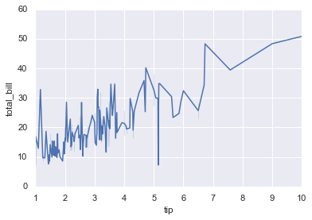

```python
sns.lineplot(data=tipData, x="tip", y="total_bill")
```

- Another dimension can be added to the plot by coloring the points according to a 3rd variable (hue).

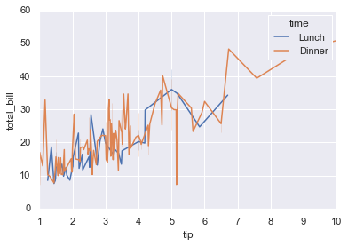

```python
sns.lineplot(data=tipData, x="tip", y="total_bill", hue="time")           # meaning?
```

### Checkpoint!

1. Load the `iris` example dataset of Seaborn.
2. Plot a line graph of your choice and interpret it.

```python
# your code goes here
```

### B. Scatter Plot

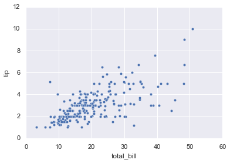

```python
sns.scatterplot(data=tipData, x="total_bill", y="tip")
```

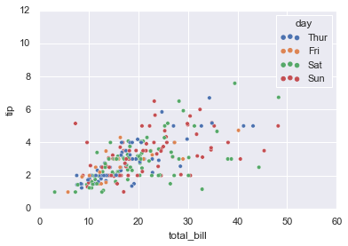

```python
sns.scatterplot(data=tipData, x="total_bill", y="tip", hue="day")       # try a different hue
```

### Checkpoint!

1. Use the `iris` dataset to plot a meaningful scatter plot.
2. Interpret the result.

```python
# your code goes here
```

### C. Distribution Plotting

- The `displot()` function is useful to visualize distributions such as histograms.
- This is useful for statistical analysis.

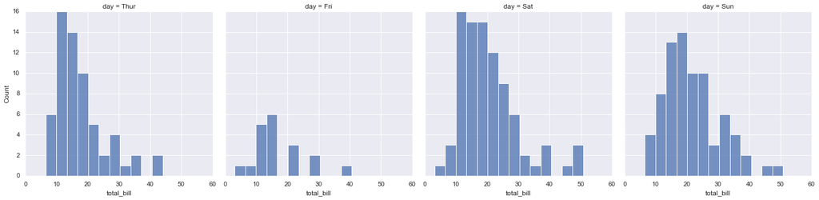

```python
sns.displot(data=tipData, x="total_bill", col="day")             # try different x and col
```

### Activity!

- Find out about the `histplot()` function of Seaborn.
- Plot a basic histogram using it.

```python
# Your code goes here
```

### D. Pair Plot

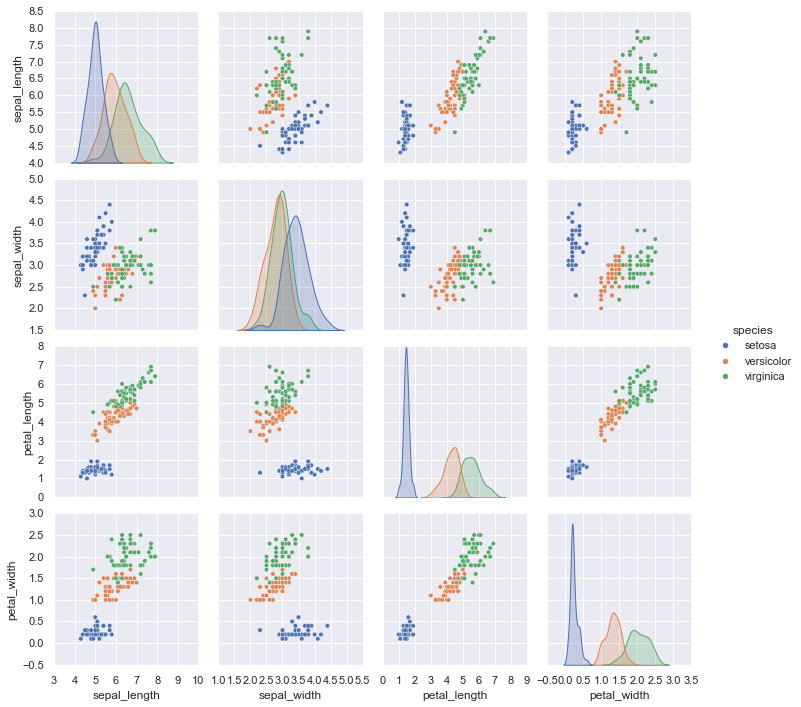

```python
#sns.pairplot(iris)
#iris
sns.pairplot(iris, hue="species")
```

### Checkpoint!

- Plot a pair plot using the `tips` dataset.
- Interpret the meaning it conveys.

### E. Box Plot

- A.k.a. a box-and-whisker plot.
- It is used to visualize distributions with respect to categories. A common use case is in times of comparing data between two groups.

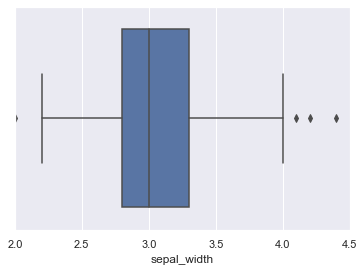

```python
sns.boxplot( iris['sepal_width'] )                                # meaning?
```

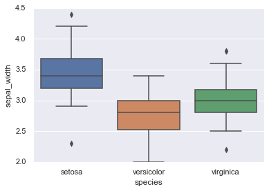

```python
sns.boxplot( x=iris['species'], y=iris['sepal_width'] )            # meaning?
```

### Checkpoint!

- Plot a box plot using the `tips` dataset.
- Interpret it.

### F. Heat Map

- It is a graphical representation where individual values of a matrix are represented as colors.
- It plots rectangular data as a color-encoded matrix.
- It helps to find patterns. A good use case is to visualize concentration of values.

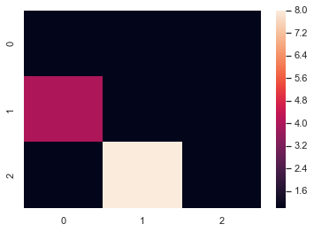

```python
# basic demo of heatmap

data = [ [1, 1, 1], [4, 1, 1], [1, 8, 1]]

sns.heatmap(data)
```

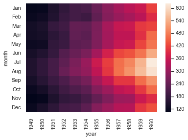

```python
# plot heatmap from an example dataset named "flights"

flights = sns.load_dataset("flights")

flights = flights.pivot("month", "year", "passengers")

sns.heatmap(flights)
```

## Other Plots

- There are many other plot types Seaborn is capable of plotting.
- See the [example gallery](https://seaborn.pydata.org/examples/index.html) at the offial site.
- See the [user guide and tutorials](https://seaborn.pydata.org/tutorial.html) too.